# Package Interconnection

Dewi Lestari Amaliah

03/09/2021

# 1 Interaction

Interaction between packages could indicate of how developers utilize the functionality of one or more packages to create new features in their packages. According to Stanstrup et al. (2019), dependency and connectivity in terms of reusing codes and inheriting objects could reflect a well-connected and interacting community. In this paper, we observe the interaction limited to only between packages that are listed as DoE packages. Further, the type of interaction include the depended, imported, and suggested packages. Out of 109, there are only 43 (39.45%) packages that interplay each other. This number is relatively lower compared to the percentage of interaction in the packages in Survey and Time Series Analysis CRAN Task View. We found that 55.3% Survey packages that depends, imports, and suggests each other, while these interconnection is observed in 62.72% Time Series Analysis packages.

Further, we observe the interaction in DoE package using network visualisation using `igraph` (Csardi and Nepusz 2006), `tidygraph` (Pedersen 2020), and `ggraph` (Pedersen 2021).

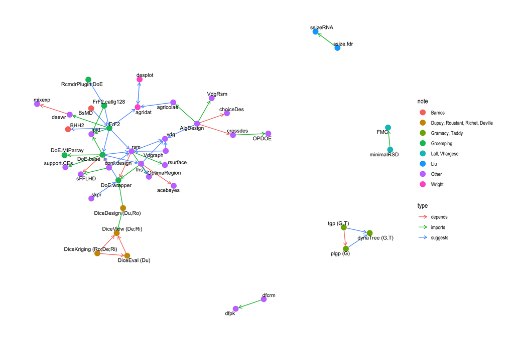

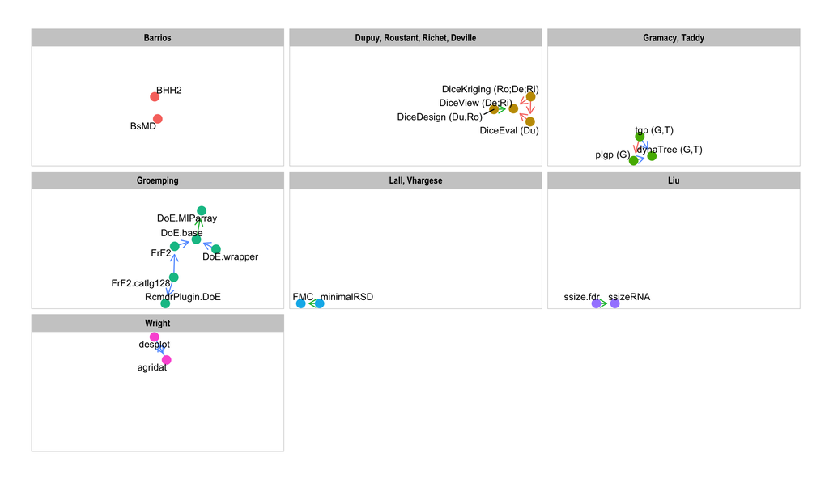

Figure 1.1 shows the interplay of DoE packages. The most downloaded DoE packages, such as `AlgDesign`, `rsm`, and `lhs` are observed to support many other packages. Dependent packages seems to use their functions to support their feature. We also observe that `DoE.base` and `FrF2`, which are created by the same author, Ulrike Groemping, are also imported, depended, and suggested by many other packages because of their basic functionality in experimental design. Moreover, some of interacting packages, such as `DoE.wrapper` and `DoE.MIParray` are also developed by Groemping.

Further, packages regarding computer experiment (`DiceKriging`, `DiceEval`, `DiceView`, and `DiceDesign`) happen to interplay with each other so that they appear to form a sub-cluster. The four smaller clusters interact because of the similarity in their type and domain. For example `dfcm` and `dfpk` are used for dose-finding experiments. Regarding the similarity of its objective, although `FMC` aims to generate factorial design, this package does not interact with the packages in the big cluster, even though some packages in this cluster, such as `DoE.base`, also involve factorial design. This package instead imports `minimalRSD`, which is developed by the same author. This is also observed in the smaller network involves `dynaTree`, `plgp`, and `tgp`. These three interplaying package are authored by the same author as well.

Based on this network, we can say that the interconnection of DoE package is due to functionality dependence, similarity of type or domain, and because they are developed by the same author/s.

[interactive chart not shown]

Csardi, Gabor, and Tamas Nepusz. 2006. “The Igraph Software Package for Complex Network Research.” *InterJournal* Complex Systems: 1695. http://igraph.org.

Pedersen, Thomas Lin. 2020. *Tidygraph: A Tidy Api for Graph Manipulation*. https://CRAN.R-project.org/package=tidygraph.

———. 2021. *Ggraph: An Implementation of Grammar of Graphics for Graphs and Networks*. https://CRAN.R-project.org/package=ggraph.

Stanstrup, Jan, Corey D Broeckling, Rick Helmus, Nils Hoffmann, Ewy Mathe, Thomas Naake, Luca Nicolotti, et al. 2019. “The metaRbolomics Toolbox in Bioconductor and Beyond.” *Metabolites* 9 (10): 200.